# Exploratory Data Analysis of Prosper Loan Data

### 4.1.7 Linear Regression Models for the BorrowerRate

The BorrowrRate would be the the model result from Prosper Rating. I then include one more variable: DebtToIncomeRatio. The model seems to be a good fi , the Adjusted R^2 is 0.9. The P value for the DebtToIncomeRatio is 0.45 which indicates the DebtToIncome didn’t play any role in the model. I also put the stated monthly income, it has the same issue.

```
##
## Call:
## lm(formula = BorrowerRate ~ ProsperRating..Alpha. + DebtToIncomeRatio,
##     data = loan.st_grouped)
##
## Residuals:
##       Min        1Q    Median        3Q       Max
## -0.141015 -0.014155 -0.000408  0.011916  0.155738
##
## Coefficients:
##                          Estimate Std. Error t value Pr(>|t|)
## (Intercept)             0.0790276  0.0003048 259.306   <2e-16 ***
## ProsperRating..Alpha.A  0.0339134  0.0003541  95.773   <2e-16 ***
## ProsperRating..Alpha.B  0.0755581  0.0003512 215.126   <2e-16 ***
## ProsperRating..Alpha.C  0.1152154  0.0003456 333.393   <2e-16 ***
## ProsperRating..Alpha.D  0.1669251  0.0003580 466.214   <2e-16 ***
## ProsperRating..Alpha.E  0.2137724  0.0003825 558.851   <2e-16 ***
## ProsperRating..Alpha.HR 0.2384641  0.0004187 569.491   <2e-16 ***
## DebtToIncomeRatio       0.0001853  0.0002469   0.751    0.453
## ---
## Signif. codes:  0 '***' 0.001 '**' 0.01 '*' 0.05 '.' 0.1 ' ' 1
##
## Residual standard error: 0.02166 on 77549 degrees of freedom
##   (36380 observations deleted due to missingness)
## Multiple R-squared:  0.9141, Adjusted R-squared:  0.9141
## F-statistic: 1.179e+05 on 7 and 77549 DF,  p-value: < 2.2e-16
```

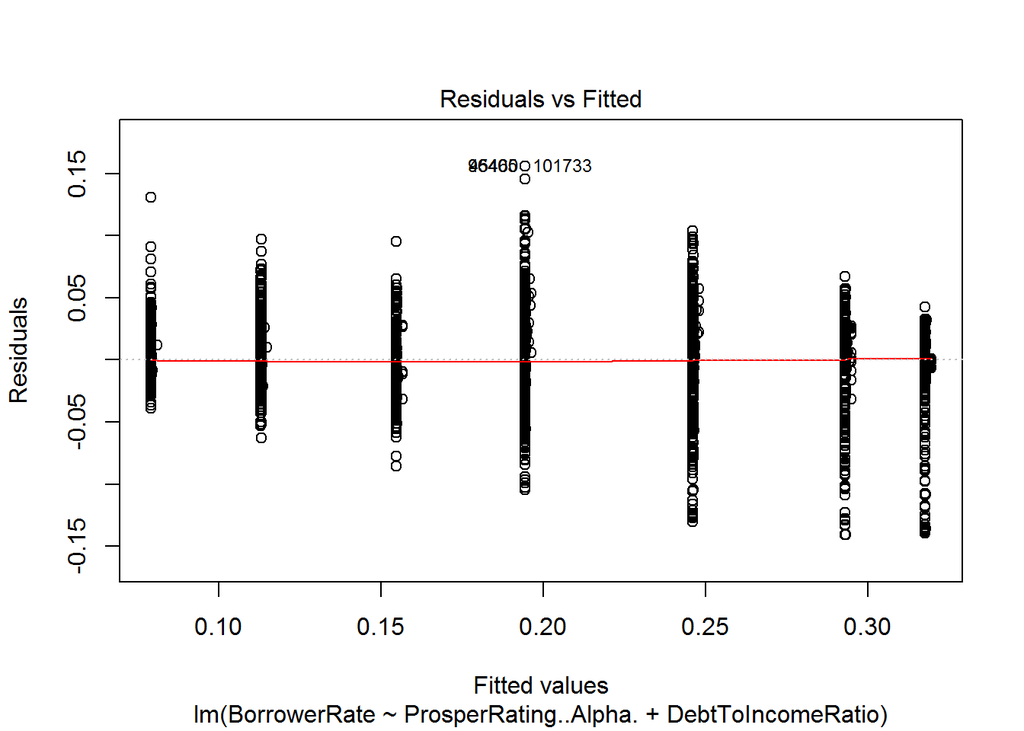

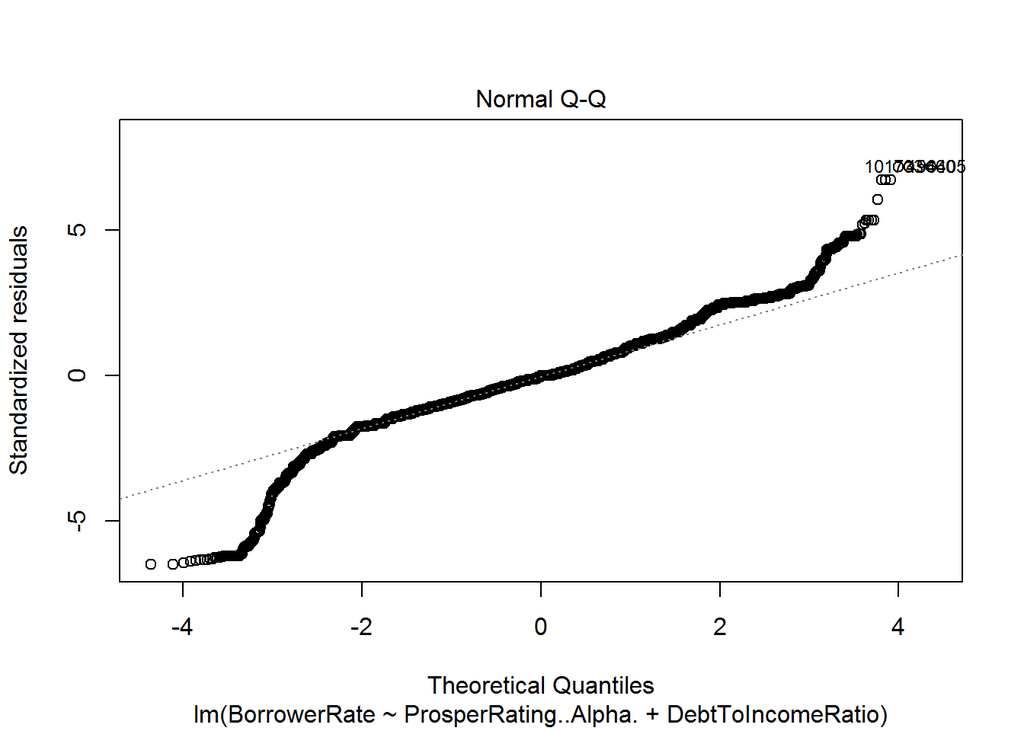

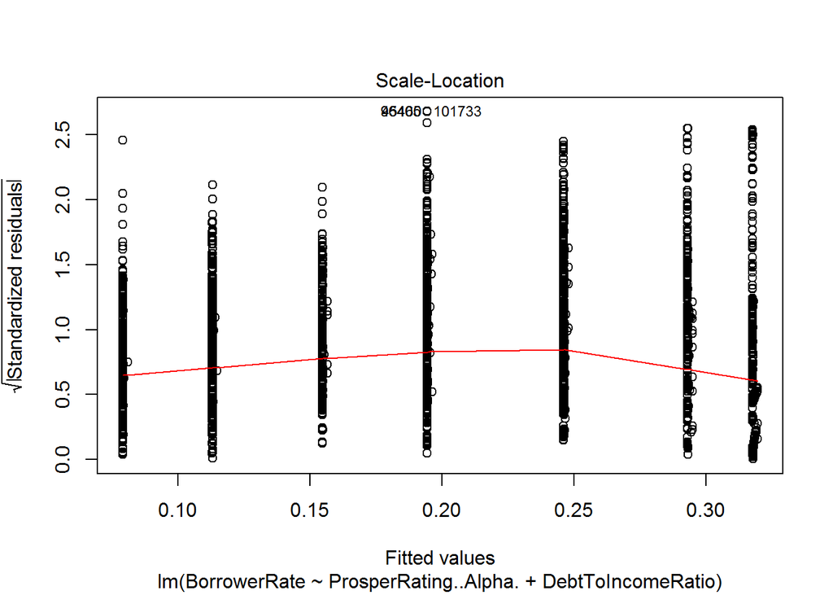

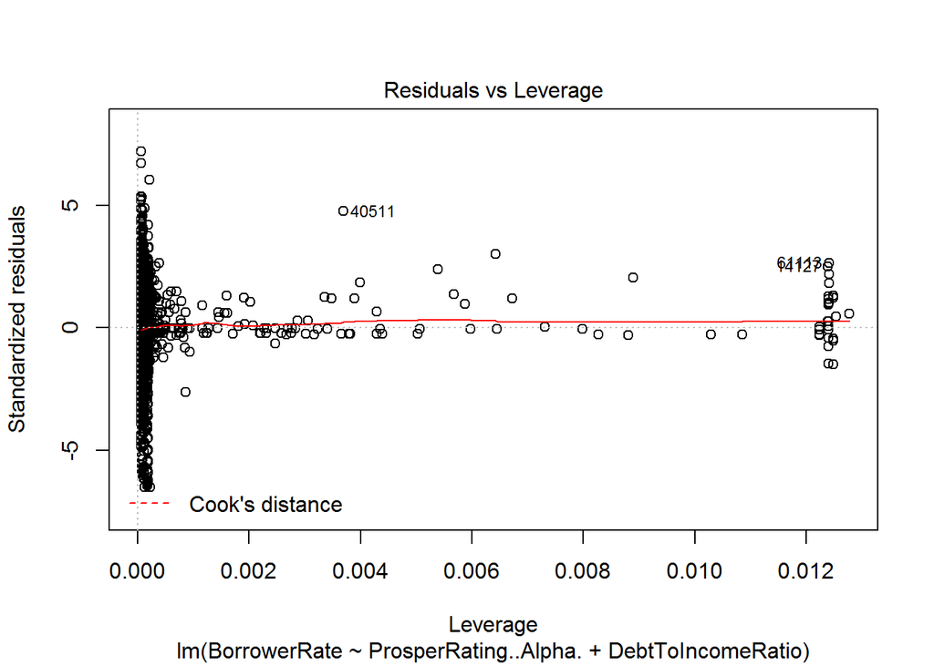

### 4.1.8 Logistic Regression Models for the Loan Status

I create a new dummy variable, loanstatusnew. If it’s Chargedoff or Default, I will say it’s a bad loan, and the loanstatusnew will be 1, otherwise it will be 0. Then I use glm to do the logistic regression analysis. The result shows the three variables are significant related to the loan status.

```
##
## Call:
## glm(formula = loanstatusnew ~ BorrowerRate + DebtToIncomeRatio +
##     CurrentDelinquencies, family = binomial("logit"), data = loan.st_grouped)
##
## Deviance Residuals:
##     Min       1Q   Median       3Q      Max
## -3.8735  -0.6109  -0.4709  -0.3733   2.5730
##
## Coefficients:
##                       Estimate Std. Error z value Pr(>|z|)
## (Intercept)          -3.391905   0.027827 -121.89   <2e-16 ***
## BorrowerRate          7.611746   0.120473   63.18   <2e-16 ***
## DebtToIncomeRatio     0.170813   0.012035   14.19   <2e-16 ***
## CurrentDelinquencies  0.177668   0.004001   44.41   <2e-16 ***
## ---
## Signif. codes:  0 '***' 0.001 '**' 0.01 '*' 0.05 '.' 0.1 ' ' 1
##
## (Dispersion parameter for binomial family taken to be 1)
##
##     Null deviance: 93580  on 104797  degrees of freedom
## Residual deviance: 85527  on 104794  degrees of freedom
##   (9139 observations deleted due to missingness)
## AIC: 85535
##
## Number of Fisher Scoring iterations: 5
```

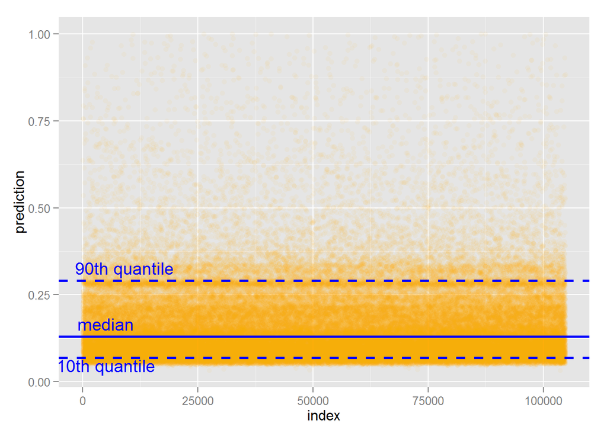

## 4.2 Multivariate Analysis

### 4.2.1 Talk about some of the relationships you observed in this part of the investigation. Were there features that strengthened each other in terms of looking at your feature(s) of interest?

For the Borrower Rate, Prosper Rating and Loan Status, we can see a clearly pattern in the graph. They actually strengthened each other. For the stated monthly income and open credit line, they actually didn’t play a role in the relationship for the prosper rating and loan status.

### 4.2.2 Were there any interesting or surprising interactions between features?

I thought the stated monthly Income would have a strong relationship with the loan status, but it turns out not that significant. And the other part is that the Borrower rate seems to be the direct result of the Prosper Rating, even I add the Debt To Income Ratio, it won’t play any roles there.

### 4.2.3 OPTIONAL: Did you create any models with your dataset? Discuss the strengths and limitations of your model.

I created two models, one is linear regression model for the borrower rate, the other one is the logistci regression model to predict the bad loans. The good thing is we can get a quantative analysis from the model result, like P value, R square, then we can say how strong the relationship is not just based on the graphs.

The models are not perfect, and we can see that the borrower rate actually is highly correlated with the Prosper Rating, which already separates the loans by risk, this seems like a circle. I try to clean the variables in the model, and do more data transformation, but it’s not that succesfull due to the limitation of the statistics knowledge. I also did see people use the hazard model to analyze the default rates wihch will be a good start for the next stage analysis.

# 5 Final Plots and Summary

## 5.1 Plot One and Description

### 5.1.1 Plot One

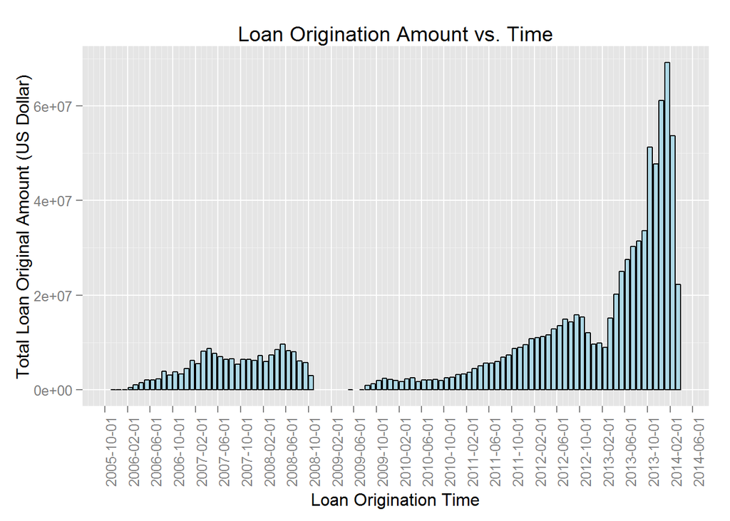

### 5.1.2 Description One

First plot shows the overall Prosper business. The Prosper was the first P2P online lending company, it provides a direct lending bridge for the borrowers and investors. The business was started back to early 2006, and it grows very quickly until 2007. It slowed down from 2007 to 2008, and followed a quiet period from Oct, 2008 to July, 2009 due to finance crisis and more restricted regulation. It shows a steady growth after 2009. The most surprising part is the loan origination amount. If we look at the loan origination amount in 2013, it’s about 4 to 5 times in 2008. More and more similar companies are in market now. LendingClub and On deck are the top two companies in the online lending industry, they both went to IPO last year.

## 5.2 Plot Two and Analysis

### 5.2.1 Plot Two

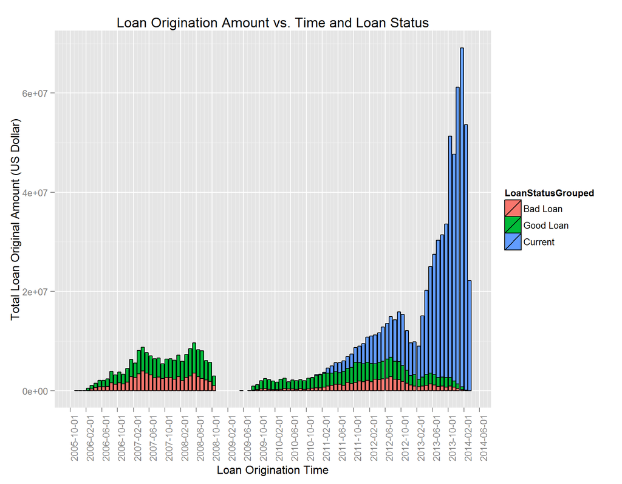

### 5.2.2 Description Two

In the second plot, we will look at the loan performance. The key question to the online investors is like “will the loan be default before I get my money back?” etc. And we see the percentage of bad loans are higher in pre the quite period in 2008 than afterwards. The high default rate prior the quite period because of the less regulation and unmature indursty at that time. After the finanicial crisis, both the investers and Prosper adapted new methods to control the risk

## 5.3 Plot Three and Decription

### 5.3.1 Plot Three

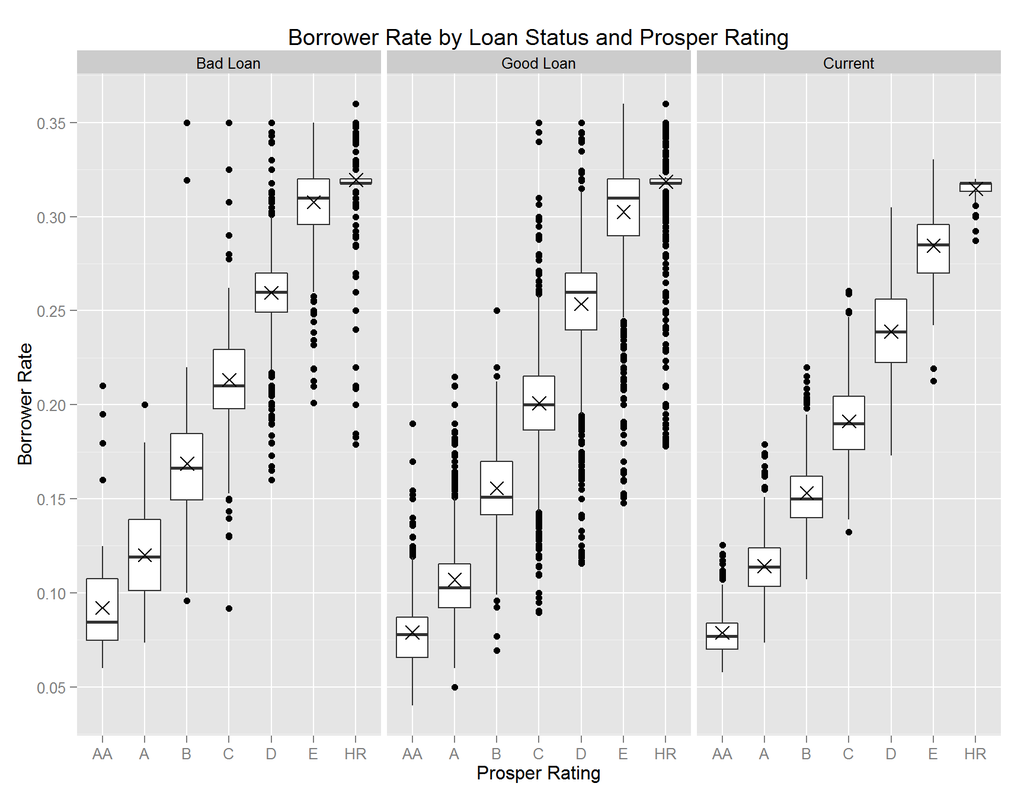

# 6 Reflection

The project turns out to be more difficult than I expected. I struggled but also learned a lot. One of the difficulty I faced is to understand the variables. Without much background in fiance, I have to do quite some research what does each variable mean. The other difficulty is that this project seems to be quite open ended. It does not come with a question for me to answer. I need to first find different questions and then explore the answers. The process becomes quite frustrating if I create a series of plots but fail to tell any stories from the plots generated. But I guess that is the nature of exploratory data analysis. We need to keep trying different things and look at the data from different angles.

Two crude models were created in this study to predict borrower rate and loan status. However, these models obviously need further improvement. The next natural step is to improve the model quality. Including other variables, such as IncomeVerifiable, AmountDelinquent etc., into the model, might be helpful to imporve the prediction accuracy.